# Risk Factor Analysis

## Outcome Variable

**Outcome Variable:** ever_co

## Predictor Variables

**Intervention Variable:** exclfeed3

**Adjustment Set:**

- arm
- sex
- brthmon
- W_mage
- meducyrs
- feducyrs
- hhwealth_quart
- hfoodsec
- W_mhtcm
- W_mwtkg
- W_mbmi
- vagbrth
- W_gagebrth
- W_birthwt
- W_birthlen
- W_nrooms
- W_nchldlt5
- month
- W_parity
- impfloor
- impsan
- safeh20
- delta_W_mage
- delta_meducyrs
- delta_feducyrs
- delta_hhwealth_quart
- delta_hfoodsec
- delta_W_mhtcm
- delta_W_mwtkg
- delta_W_mbmi
- delta_vagbrth
- delta_W_gagebrth
- delta_W_birthwt
- delta_W_birthlen
- delta_W_nrooms
- delta_W_nchldlt5
- delta_month
- delta_W_parity
- delta_impfloor
- delta_impsan
- delta_safeh20

## Stratifying Variables

The analysis was stratified on these variable(s):

- agecat
- studyid
- country

## Data Summary

| agecat | studyid | country | exclfeed3 | ever_co | n_cell | n |
| --- | --- | --- | --- | --- | --- | --- |
| 0-24 months | ki0047075b-MAL-ED | BANGLADESH | 1 | 0 | 132 | 244 |
| 0-24 months | ki0047075b-MAL-ED | BANGLADESH | 1 | 1 | 27 | 244 |
| 0-24 months | ki0047075b-MAL-ED | BANGLADESH | 0 | 0 | 74 | 244 |
| 0-24 months | ki0047075b-MAL-ED | BANGLADESH | 0 | 1 | 11 | 244 |
| 0-24 months | ki0047075b-MAL-ED | BRAZIL | 1 | 0 | 62 | 202 |
| 0-24 months | ki0047075b-MAL-ED | BRAZIL | 1 | 1 | 2 | 202 |
| 0-24 months | ki0047075b-MAL-ED | BRAZIL | 0 | 0 | 137 | 202 |
| 0-24 months | ki0047075b-MAL-ED | BRAZIL | 0 | 1 | 1 | 202 |
| 0-24 months | ki0047075b-MAL-ED | INDIA | 1 | 0 | 91 | 216 |
| 0-24 months | ki0047075b-MAL-ED | INDIA | 1 | 1 | 22 | 216 |
| 0-24 months | ki0047075b-MAL-ED | INDIA | 0 | 0 | 76 | 216 |
| 0-24 months | ki0047075b-MAL-ED | INDIA | 0 | 1 | 27 | 216 |
| 0-24 months | ki0047075b-MAL-ED | NEPAL | 1 | 0 | 62 | 228 |
| 0-24 months | ki0047075b-MAL-ED | NEPAL | 1 | 1 | 9 | 228 |
| 0-24 months | ki0047075b-MAL-ED | NEPAL | 0 | 0 | 145 | 228 |
| 0-24 months | ki0047075b-MAL-ED | NEPAL | 0 | 1 | 12 | 228 |
| 0-24 months | ki0047075b-MAL-ED | PERU | 1 | 0 | 62 | 287 |
| 0-24 months | ki0047075b-MAL-ED | PERU | 1 | 1 | 2 | 287 |
| 0-24 months | ki0047075b-MAL-ED | PERU | 0 | 0 | 214 | 287 |
| 0-24 months | ki0047075b-MAL-ED | PERU | 0 | 1 | 9 | 287 |
| 0-24 months | ki0047075b-MAL-ED | SOUTH AFRICA | 1 | 0 | 25 | 269 |
| 0-24 months | ki0047075b-MAL-ED | SOUTH AFRICA | 1 | 1 | 0 | 269 |
| 0-24 months | ki0047075b-MAL-ED | SOUTH AFRICA | 0 | 0 | 223 | 269 |
| 0-24 months | ki0047075b-MAL-ED | SOUTH AFRICA | 0 | 1 | 21 | 269 |
| 0-24 months | ki0047075b-MAL-ED | TANZANIA, UNITED REPUBLIC OF | 1 | 0 | 46 | 219 |
| 0-24 months | ki0047075b-MAL-ED | TANZANIA, UNITED REPUBLIC OF | 1 | 1 | 1 | 219 |
| 0-24 months | ki0047075b-MAL-ED | TANZANIA, UNITED REPUBLIC OF | 0 | 0 | 154 | 219 |
| 0-24 months | ki0047075b-MAL-ED | TANZANIA, UNITED REPUBLIC OF | 0 | 1 | 18 | 219 |
| 0-24 months | ki1000108-CMC-V-BCS-2002 | INDIA | 1 | 0 | 7 | 10 |
| 0-24 months | ki1000108-CMC-V-BCS-2002 | INDIA | 1 | 1 | 3 | 10 |

[output cut: 162 more lines]

The following strata were considered:

- agecat: 0-24 months, studyid: ki0047075b-MAL-ED, country: BANGLADESH
- agecat: 0-24 months, studyid: ki0047075b-MAL-ED, country: BRAZIL
- agecat: 0-24 months, studyid: ki0047075b-MAL-ED, country: INDIA
- agecat: 0-24 months, studyid: ki0047075b-MAL-ED, country: NEPAL
- agecat: 0-24 months, studyid: ki0047075b-MAL-ED, country: PERU
- agecat: 0-24 months, studyid: ki0047075b-MAL-ED, country: SOUTH AFRICA
- agecat: 0-24 months, studyid: ki0047075b-MAL-ED, country: TANZANIA, UNITED REPUBLIC OF
- agecat: 0-24 months, studyid: ki1000108-CMC-V-BCS-2002, country: INDIA
- agecat: 0-24 months, studyid: ki1000108-IRC, country: INDIA
- agecat: 0-24 months, studyid: ki1000109-EE, country: PAKISTAN
- agecat: 0-24 months, studyid: ki1000304b-SAS-CompFeed, country: INDIA
- agecat: 0-24 months, studyid: ki1017093b-PROVIDE, country: BANGLADESH
- agecat: 0-24 months, studyid: ki1101329-Keneba, country: GAMBIA
- agecat: 0-24 months, studyid: ki1113344-GMS-Nepal, country: NEPAL
- agecat: 0-24 months, studyid: kiGH5241-JiVitA-3, country: BANGLADESH
- agecat: 0-24 months, studyid: kiGH5241-JiVitA-4, country: BANGLADESH
- agecat: 0-6 months, studyid: ki0047075b-MAL-ED, country: BANGLADESH
- agecat: 0-6 months, studyid: ki0047075b-MAL-ED, country: BRAZIL
- agecat: 0-6 months, studyid: ki0047075b-MAL-ED, country: INDIA
- agecat: 0-6 months, studyid: ki0047075b-MAL-ED, country: NEPAL
- agecat: 0-6 months, studyid: ki0047075b-MAL-ED, country: PERU
- agecat: 0-6 months, studyid: ki0047075b-MAL-ED, country: SOUTH AFRICA
- agecat: 0-6 months, studyid: ki0047075b-MAL-ED, country: TANZANIA, UNITED REPUBLIC OF
- agecat: 0-6 months, studyid: ki1000108-CMC-V-BCS-2002, country: INDIA
- agecat: 0-6 months, studyid: ki1000108-IRC, country: INDIA
- agecat: 0-6 months, studyid: ki1000109-EE, country: PAKISTAN
- agecat: 0-6 months, studyid: ki1000304b-SAS-CompFeed, country: INDIA
- agecat: 0-6 months, studyid: ki1017093b-PROVIDE, country: BANGLADESH
- agecat: 0-6 months, studyid: ki1101329-Keneba, country: GAMBIA
- agecat: 0-6 months, studyid: ki1113344-GMS-Nepal, country: NEPAL
- agecat: 0-6 months, studyid: kiGH5241-JiVitA-3, country: BANGLADESH
- agecat: 0-6 months, studyid: kiGH5241-JiVitA-4, country: BANGLADESH
- agecat: 6-24 months, studyid: ki0047075b-MAL-ED, country: BANGLADESH
- agecat: 6-24 months, studyid: ki0047075b-MAL-ED, country: BRAZIL
- agecat: 6-24 months, studyid: ki0047075b-MAL-ED, country: INDIA
- agecat: 6-24 months, studyid: ki0047075b-MAL-ED, country: NEPAL
- agecat: 6-24 months, studyid: ki0047075b-MAL-ED, country: PERU
- agecat: 6-24 months, studyid: ki0047075b-MAL-ED, country: SOUTH AFRICA
- agecat: 6-24 months, studyid: ki0047075b-MAL-ED, country: TANZANIA, UNITED REPUBLIC OF
- agecat: 6-24 months, studyid: ki1000108-CMC-V-BCS-2002, country: INDIA
- agecat: 6-24 months, studyid: ki1000108-IRC, country: INDIA
- agecat: 6-24 months, studyid: ki1000109-EE, country: PAKISTAN
- agecat: 6-24 months, studyid: ki1000304b-SAS-CompFeed, country: INDIA
- agecat: 6-24 months, studyid: ki1017093b-PROVIDE, country: BANGLADESH
- agecat: 6-24 months, studyid: ki1101329-Keneba, country: GAMBIA
- agecat: 6-24 months, studyid: ki1113344-GMS-Nepal, country: NEPAL
- agecat: 6-24 months, studyid: kiGH5241-JiVitA-3, country: BANGLADESH
- agecat: 6-24 months, studyid: kiGH5241-JiVitA-4, country: BANGLADESH

### Dropped Strata

Some strata were dropped due to rare outcomes:

- agecat: 0-24 months, studyid: ki0047075b-MAL-ED, country: BRAZIL
- agecat: 0-24 months, studyid: ki0047075b-MAL-ED, country: PERU
- agecat: 0-24 months, studyid: ki0047075b-MAL-ED, country: SOUTH AFRICA
- agecat: 0-24 months, studyid: ki0047075b-MAL-ED, country: TANZANIA, UNITED REPUBLIC OF
- agecat: 0-24 months, studyid: ki1000108-CMC-V-BCS-2002, country: INDIA
- agecat: 0-24 months, studyid: ki1000108-IRC, country: INDIA
- agecat: 0-24 months, studyid: ki1000109-EE, country: PAKISTAN
- agecat: 0-24 months, studyid: kiGH5241-JiVitA-4, country: BANGLADESH
- agecat: 0-6 months, studyid: ki0047075b-MAL-ED, country: BANGLADESH
- agecat: 0-6 months, studyid: ki0047075b-MAL-ED, country: BRAZIL
- agecat: 0-6 months, studyid: ki0047075b-MAL-ED, country: NEPAL
- agecat: 0-6 months, studyid: ki0047075b-MAL-ED, country: PERU
- agecat: 0-6 months, studyid: ki0047075b-MAL-ED, country: SOUTH AFRICA
- agecat: 0-6 months, studyid: ki0047075b-MAL-ED, country: TANZANIA, UNITED REPUBLIC OF
- agecat: 0-6 months, studyid: ki1000108-CMC-V-BCS-2002, country: INDIA
- agecat: 0-6 months, studyid: ki1000108-IRC, country: INDIA
- agecat: 0-6 months, studyid: ki1000109-EE, country: PAKISTAN
- agecat: 0-6 months, studyid: ki1000304b-SAS-CompFeed, country: INDIA
- agecat: 0-6 months, studyid: kiGH5241-JiVitA-4, country: BANGLADESH
- agecat: 6-24 months, studyid: ki0047075b-MAL-ED, country: BRAZIL
- agecat: 6-24 months, studyid: ki0047075b-MAL-ED, country: PERU
- agecat: 6-24 months, studyid: ki0047075b-MAL-ED, country: SOUTH AFRICA
- agecat: 6-24 months, studyid: ki0047075b-MAL-ED, country: TANZANIA, UNITED REPUBLIC OF
- agecat: 6-24 months, studyid: ki1000108-CMC-V-BCS-2002, country: INDIA
- agecat: 6-24 months, studyid: ki1000108-IRC, country: INDIA
- agecat: 6-24 months, studyid: ki1000109-EE, country: PAKISTAN
- agecat: 6-24 months, studyid: kiGH5241-JiVitA-4, country: BANGLADESH

## Methods Detail

We’re interested in the causal parameters $E[Y_a]$ for all values of $a \in \mathcal{A}$. These parameters represent the mean outcome if, possibly contrary to fact, we intervened to set all units to have $A=a$. Under the randomization and positivity assumptions, these are identified by the statistical parameters $\psi_a=E_W[E_{Y|A,W}(Y|A=a,W)]$. In addition, we’re interested in the mean of $Y$, $E[Y]$ under no intervention (the observed mean). We will estimate these parameters by using SuperLearner to fit the relevant likelihood factors – $E_{Y|A,W}(Y|A=a,W)$ and $p(A=a|W)$, and then updating our likelihood fit using a joint TMLE.

For unadjusted analyses ($W=\{\}$), initial likelihoods were estimated using Lrnr_glm to estimate the simple $E(Y|A)$ and Lrnr_mean to estimate $p(A)$. For adjusted analyses, a small library containing Lrnr_glmnet, Lrnr_xgboost, and Lrnr_mean was used.

Having estimated these parameters, we will then use the delta method to estimate relative risks and attributable risks relative to a prespecified baseline level of $A$.

# Results Detail

## Results Plots

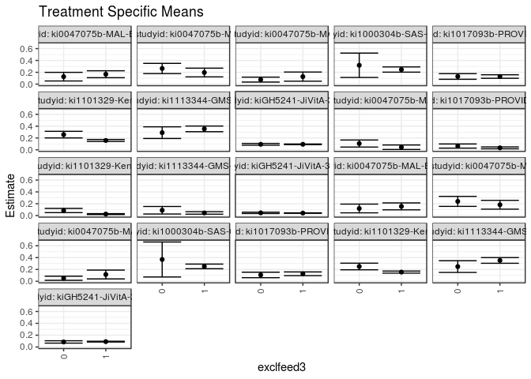

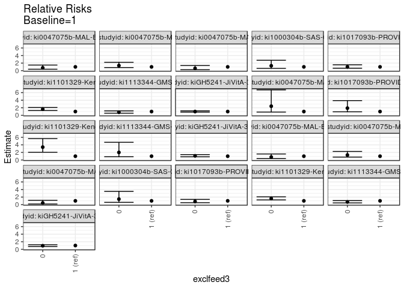

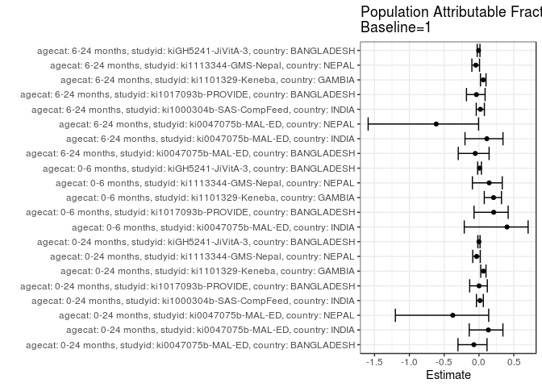

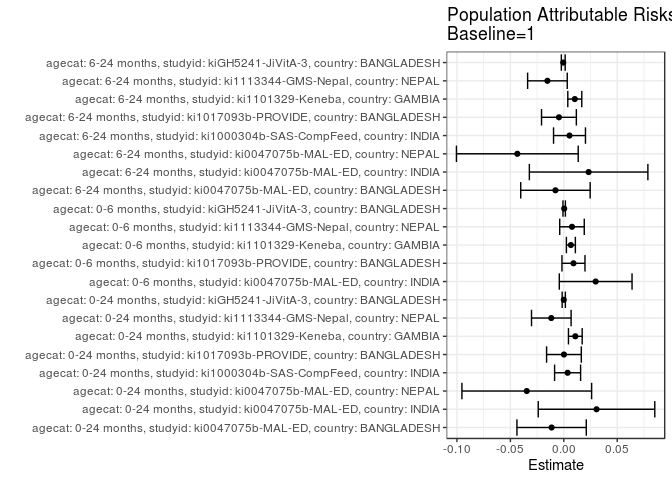

## Results Table

### Parameter: TSM

| agecat | studyid | country | intervention_level | baseline_level | estimate | ci_lower | ci_upper |
| --- | --- | --- | --- | --- | --- | --- | --- |
| 0-24 months | ki0047075b-MAL-ED | BANGLADESH | 1 | NA | 0.1671472 | 0.1084836 | 0.2258107 |
| 0-24 months | ki0047075b-MAL-ED | BANGLADESH | 0 | NA | 0.1260104 | 0.0529559 | 0.1990650 |
| 0-24 months | ki0047075b-MAL-ED | INDIA | 1 | NA | 0.1962411 | 0.1225675 | 0.2699147 |
| 0-24 months | ki0047075b-MAL-ED | INDIA | 0 | NA | 0.2641616 | 0.1777400 | 0.3505833 |
| 0-24 months | ki0047075b-MAL-ED | NEPAL | 1 | NA | 0.1267606 | 0.0492016 | 0.2043196 |
| 0-24 months | ki0047075b-MAL-ED | NEPAL | 0 | NA | 0.0764331 | 0.0347819 | 0.1180843 |
| 0-24 months | ki1000304b-SAS-CompFeed | INDIA | 1 | NA | 0.2464455 | 0.2022875 | 0.2906035 |
| 0-24 months | ki1000304b-SAS-CompFeed | INDIA | 0 | NA | 0.3181818 | 0.1124254 | 0.5239382 |
| 0-24 months | ki1017093b-PROVIDE | BANGLADESH | 1 | NA | 0.1284308 | 0.0988568 | 0.1580047 |
| 0-24 months | ki1017093b-PROVIDE | BANGLADESH | 0 | NA | 0.1293151 | 0.0818873 | 0.1767428 |
| 0-24 months | ki1101329-Keneba | GAMBIA | 1 | NA | 0.1581177 | 0.1412835 | 0.1749518 |
| 0-24 months | ki1101329-Keneba | GAMBIA | 0 | NA | 0.2571862 | 0.2014745 | 0.3128979 |
| 0-24 months | ki1113344-GMS-Nepal | NEPAL | 1 | NA | 0.3544872 | 0.3066054 | 0.4023689 |
| 0-24 months | ki1113344-GMS-Nepal | NEPAL | 0 | NA | 0.2904123 | 0.1918858 | 0.3889388 |
| 0-24 months | kiGH5241-JiVitA-3 | BANGLADESH | 1 | NA | 0.0934834 | 0.0881825 | 0.0987842 |
| 0-24 months | kiGH5241-JiVitA-3 | BANGLADESH | 0 | NA | 0.0935491 | 0.0786456 | 0.1084526 |
| 0-6 months | ki0047075b-MAL-ED | INDIA | 1 | NA | 0.0442478 | 0.0062433 | 0.0822523 |
| 0-6 months | ki0047075b-MAL-ED | INDIA | 0 | NA | 0.1067961 | 0.0470114 | 0.1665808 |
| 0-6 months | ki1017093b-PROVIDE | BANGLADESH | 1 | NA | 0.0338070 | 0.0179871 | 0.0496269 |
| 0-6 months | ki1017093b-PROVIDE | BANGLADESH | 0 | NA | 0.0641520 | 0.0290993 | 0.0992047 |
| 0-6 months | ki1101329-Keneba | GAMBIA | 1 | NA | 0.0250718 | 0.0178485 | 0.0322951 |
| 0-6 months | ki1101329-Keneba | GAMBIA | 0 | NA | 0.0852007 | 0.0492817 | 0.1211197 |
| 0-6 months | ki1113344-GMS-Nepal | NEPAL | 1 | NA | 0.0447368 | 0.0239291 | 0.0655446 |
| 0-6 months | ki1113344-GMS-Nepal | NEPAL | 0 | NA | 0.0897436 | 0.0262457 | 0.1532414 |
| 0-6 months | kiGH5241-JiVitA-3 | BANGLADESH | 1 | NA | 0.0421714 | 0.0384454 | 0.0458974 |
| 0-6 months | kiGH5241-JiVitA-3 | BANGLADESH | 0 | NA | 0.0460307 | 0.0348802 | 0.0571812 |
| 6-24 months | ki0047075b-MAL-ED | BANGLADESH | 1 | NA | 0.1550122 | 0.0964495 | 0.2135749 |
| 6-24 months | ki0047075b-MAL-ED | BANGLADESH | 0 | NA | 0.1196579 | 0.0459837 | 0.1933321 |
| 6-24 months | ki0047075b-MAL-ED | INDIA | 1 | NA | 0.1825124 | 0.1080460 | 0.2569788 |
| 6-24 months | ki0047075b-MAL-ED | INDIA | 0 | NA | 0.2396259 | 0.1552058 | 0.3240460 |
| 6-24 months | ki0047075b-MAL-ED | NEPAL | 1 | NA | 0.1142857 | 0.0395884 | 0.1889830 |
| 6-24 months | ki0047075b-MAL-ED | NEPAL | 0 | NA | 0.0512821 | 0.0165924 | 0.0859717 |
| 6-24 months | ki1000304b-SAS-CompFeed | INDIA | 1 | NA | 0.2512563 | 0.2120897 | 0.2904228 |
| 6-24 months | ki1000304b-SAS-CompFeed | INDIA | 0 | NA | 0.3684211 | 0.0727072 | 0.6641349 |
| 6-24 months | ki1017093b-PROVIDE | BANGLADESH | 1 | NA | 0.1266963 | 0.0954352 | 0.1579574 |
| 6-24 months | ki1017093b-PROVIDE | BANGLADESH | 0 | NA | 0.1071176 | 0.0606472 | 0.1535880 |
| 6-24 months | ki1101329-Keneba | GAMBIA | 1 | NA | 0.1551579 | 0.1379548 | 0.1723610 |
| 6-24 months | ki1101329-Keneba | GAMBIA | 0 | NA | 0.2501294 | 0.1940757 | 0.3061832 |
| 6-24 months | ki1113344-GMS-Nepal | NEPAL | 1 | NA | 0.3523485 | 0.3041753 | 0.4005217 |
| 6-24 months | ki1113344-GMS-Nepal | NEPAL | 0 | NA | 0.2485617 | 0.1497170 | 0.3474063 |
| 6-24 months | kiGH5241-JiVitA-3 | BANGLADESH | 1 | NA | 0.0906415 | 0.0841467 | 0.0971364 |
| 6-24 months | kiGH5241-JiVitA-3 | BANGLADESH | 0 | NA | 0.0855440 | 0.0654959 | 0.1055922 |

### Parameter: E(Y)

| agecat | studyid | country | intervention_level | baseline_level | estimate | ci_lower | ci_upper |
| --- | --- | --- | --- | --- | --- | --- | --- |
| 0-24 months | ki0047075b-MAL-ED | BANGLADESH | NA | NA | 0.1557377 | 0.1101466 | 0.2013289 |
| 0-24 months | ki0047075b-MAL-ED | INDIA | NA | NA | 0.2268519 | 0.1708720 | 0.2828317 |
| 0-24 months | ki0047075b-MAL-ED | NEPAL | NA | NA | 0.0921053 | 0.0544873 | 0.1297232 |
| 0-24 months | ki1000304b-SAS-CompFeed | INDIA | NA | NA | 0.2500000 | 0.2118239 | 0.2881761 |
| 0-24 months | ki1017093b-PROVIDE | BANGLADESH | NA | NA | 0.1285714 | 0.1037574 | 0.1533855 |
| 0-24 months | ki1101329-Keneba | GAMBIA | NA | NA | 0.1688955 | 0.1525490 | 0.1852420 |
| 0-24 months | ki1113344-GMS-Nepal | NEPAL | NA | NA | 0.3427948 | 0.2992779 | 0.3863116 |
| 0-24 months | kiGH5241-JiVitA-3 | BANGLADESH | NA | NA | 0.0934517 | 0.0884729 | 0.0984306 |
| 0-6 months | ki0047075b-MAL-ED | INDIA | NA | NA | 0.0740741 | 0.0390675 | 0.1090807 |
| 0-6 months | ki1017093b-PROVIDE | BANGLADESH | NA | NA | 0.0428571 | 0.0278427 | 0.0578716 |
| 0-6 months | ki1101329-Keneba | GAMBIA | NA | NA | 0.0316989 | 0.0240550 | 0.0393428 |
| 0-6 months | ki1113344-GMS-Nepal | NEPAL | NA | NA | 0.0524017 | 0.0319714 | 0.0728321 |
| 0-6 months | kiGH5241-JiVitA-3 | BANGLADESH | NA | NA | 0.0425304 | 0.0390546 | 0.0460063 |
| 6-24 months | ki0047075b-MAL-ED | BANGLADESH | NA | NA | 0.1471861 | 0.1013989 | 0.1929734 |
| 6-24 months | ki0047075b-MAL-ED | INDIA | NA | NA | 0.2057416 | 0.1508055 | 0.2606778 |
| 6-24 months | ki0047075b-MAL-ED | NEPAL | NA | NA | 0.0707965 | 0.0372831 | 0.1043098 |
| 6-24 months | ki1000304b-SAS-CompFeed | INDIA | NA | NA | 0.2565947 | 0.2209578 | 0.2922316 |
| 6-24 months | ki1017093b-PROVIDE | BANGLADESH | NA | NA | 0.1221498 | 0.0962275 | 0.1480722 |
| 6-24 months | ki1101329-Keneba | GAMBIA | NA | NA | 0.1654450 | 0.1487764 | 0.1821136 |
| 6-24 months | ki1113344-GMS-Nepal | NEPAL | NA | NA | 0.3370288 | 0.2933549 | 0.3807028 |
| 6-24 months | kiGH5241-JiVitA-3 | BANGLADESH | NA | NA | 0.0901332 | 0.0839189 | 0.0963475 |

### Parameter: RR

| agecat | studyid | country | intervention_level | baseline_level | estimate | ci_lower | ci_upper |
| --- | --- | --- | --- | --- | --- | --- | --- |
| 0-24 months | ki0047075b-MAL-ED | BANGLADESH | 1 | 1 | 1.0000000 | 1.0000000 | 1.000000 |
| 0-24 months | ki0047075b-MAL-ED | BANGLADESH | 0 | 1 | 0.7538893 | 0.3828713 | 1.484439 |
| 0-24 months | ki0047075b-MAL-ED | INDIA | 1 | 1 | 1.0000000 | 1.0000000 | 1.000000 |
| 0-24 months | ki0047075b-MAL-ED | INDIA | 0 | 1 | 1.3461075 | 0.8185329 | 2.213723 |
| 0-24 months | ki0047075b-MAL-ED | NEPAL | 1 | 1 | 1.0000000 | 1.0000000 | 1.000000 |
| 0-24 months | ki0047075b-MAL-ED | NEPAL | 0 | 1 | 0.6029724 | 0.2657429 | 1.368149 |
| 0-24 months | ki1000304b-SAS-CompFeed | INDIA | 1 | 1 | 1.0000000 | 1.0000000 | 1.000000 |
| 0-24 months | ki1000304b-SAS-CompFeed | INDIA | 0 | 1 | 1.2910839 | 0.6050646 | 2.754908 |
| 0-24 months | ki1017093b-PROVIDE | BANGLADESH | 1 | 1 | 1.0000000 | 1.0000000 | 1.000000 |
| 0-24 months | ki1017093b-PROVIDE | BANGLADESH | 0 | 1 | 1.0068856 | 0.6532096 | 1.552057 |
| 0-24 months | ki1101329-Keneba | GAMBIA | 1 | 1 | 1.0000000 | 1.0000000 | 1.000000 |
| 0-24 months | ki1101329-Keneba | GAMBIA | 0 | 1 | 1.6265494 | 1.2803336 | 2.066385 |
| 0-24 months | ki1113344-GMS-Nepal | NEPAL | 1 | 1 | 1.0000000 | 1.0000000 | 1.000000 |
| 0-24 months | ki1113344-GMS-Nepal | NEPAL | 0 | 1 | 0.8192462 | 0.5707873 | 1.175857 |
| 0-24 months | kiGH5241-JiVitA-3 | BANGLADESH | 1 | 1 | 1.0000000 | 1.0000000 | 1.000000 |
| 0-24 months | kiGH5241-JiVitA-3 | BANGLADESH | 0 | 1 | 1.0007034 | 0.8444043 | 1.185933 |
| 0-6 months | ki0047075b-MAL-ED | INDIA | 1 | 1 | 1.0000000 | 1.0000000 | 1.000000 |
| 0-6 months | ki0047075b-MAL-ED | INDIA | 0 | 1 | 2.4135921 | 0.8657917 | 6.728439 |
| 0-6 months | ki1017093b-PROVIDE | BANGLADESH | 1 | 1 | 1.0000000 | 1.0000000 | 1.000000 |
| 0-6 months | ki1017093b-PROVIDE | BANGLADESH | 0 | 1 | 1.8975947 | 0.9252987 | 3.891571 |
| 0-6 months | ki1101329-Keneba | GAMBIA | 1 | 1 | 1.0000000 | 1.0000000 | 1.000000 |
| 0-6 months | ki1101329-Keneba | GAMBIA | 0 | 1 | 3.3982679 | 2.0403821 | 5.659834 |
| 0-6 months | ki1113344-GMS-Nepal | NEPAL | 1 | 1 | 1.0000000 | 1.0000000 | 1.000000 |
| 0-6 months | ki1113344-GMS-Nepal | NEPAL | 0 | 1 | 2.0060331 | 0.8602152 | 4.678095 |
| 0-6 months | kiGH5241-JiVitA-3 | BANGLADESH | 1 | 1 | 1.0000000 | 1.0000000 | 1.000000 |
| 0-6 months | kiGH5241-JiVitA-3 | BANGLADESH | 0 | 1 | 1.0915152 | 0.8395761 | 1.419056 |
| 6-24 months | ki0047075b-MAL-ED | BANGLADESH | 1 | 1 | 1.0000000 | 1.0000000 | 1.000000 |
| 6-24 months | ki0047075b-MAL-ED | BANGLADESH | 0 | 1 | 0.7719256 | 0.3750105 | 1.588940 |
| 6-24 months | ki0047075b-MAL-ED | INDIA | 1 | 1 | 1.0000000 | 1.0000000 | 1.000000 |
| 6-24 months | ki0047075b-MAL-ED | INDIA | 0 | 1 | 1.3129295 | 0.7642801 | 2.255434 |
| 6-24 months | ki0047075b-MAL-ED | NEPAL | 1 | 1 | 1.0000000 | 1.0000000 | 1.000000 |
| 6-24 months | ki0047075b-MAL-ED | NEPAL | 0 | 1 | 0.4487180 | 0.1751721 | 1.149429 |
| 6-24 months | ki1000304b-SAS-CompFeed | INDIA | 1 | 1 | 1.0000000 | 1.0000000 | 1.000000 |
| 6-24 months | ki1000304b-SAS-CompFeed | INDIA | 0 | 1 | 1.4663158 | 0.6118309 | 3.514177 |
| 6-24 months | ki1017093b-PROVIDE | BANGLADESH | 1 | 1 | 1.0000000 | 1.0000000 | 1.000000 |
| 6-24 months | ki1017093b-PROVIDE | BANGLADESH | 0 | 1 | 0.8454672 | 0.5133459 | 1.392462 |
| 6-24 months | ki1101329-Keneba | GAMBIA | 1 | 1 | 1.0000000 | 1.0000000 | 1.000000 |
| 6-24 months | ki1101329-Keneba | GAMBIA | 0 | 1 | 1.6120959 | 1.2579114 | 2.066006 |
| 6-24 months | ki1113344-GMS-Nepal | NEPAL | 1 | 1 | 1.0000000 | 1.0000000 | 1.000000 |
| 6-24 months | ki1113344-GMS-Nepal | NEPAL | 0 | 1 | 0.7054427 | 0.4646546 | 1.071009 |
| 6-24 months | kiGH5241-JiVitA-3 | BANGLADESH | 1 | 1 | 1.0000000 | 1.0000000 | 1.000000 |
| 6-24 months | kiGH5241-JiVitA-3 | BANGLADESH | 0 | 1 | 0.9437619 | 0.7396702 | 1.204167 |

### Parameter: PAR

| agecat | studyid | country | intervention_level | baseline_level | estimate | ci_lower | ci_upper |
| --- | --- | --- | --- | --- | --- | --- | --- |
| 0-24 months | ki0047075b-MAL-ED | BANGLADESH | 1 | NA | -0.0114095 | -0.0438566 | 0.0210376 |
| 0-24 months | ki0047075b-MAL-ED | INDIA | 1 | NA | 0.0306107 | -0.0239251 | 0.0851466 |
| 0-24 months | ki0047075b-MAL-ED | NEPAL | 1 | NA | -0.0346553 | -0.0953519 | 0.0260413 |
| 0-24 months | ki1000304b-SAS-CompFeed | INDIA | 1 | NA | 0.0035545 | -0.0086130 | 0.0157220 |
| 0-24 months | ki1017093b-PROVIDE | BANGLADESH | 1 | NA | 0.0001407 | -0.0161076 | 0.0163889 |
| 0-24 months | ki1101329-Keneba | GAMBIA | 1 | NA | 0.0107778 | 0.0043625 | 0.0171931 |
| 0-24 months | ki1113344-GMS-Nepal | NEPAL | 1 | NA | -0.0116924 | -0.0302157 | 0.0068309 |
| 0-24 months | kiGH5241-JiVitA-3 | BANGLADESH | 1 | NA | -0.0000316 | -0.0015348 | 0.0014715 |
| 0-6 months | ki0047075b-MAL-ED | INDIA | 1 | NA | 0.0298263 | -0.0042119 | 0.0638644 |
| 0-6 months | ki1017093b-PROVIDE | BANGLADESH | 1 | NA | 0.0090501 | -0.0017186 | 0.0198189 |
| 0-6 months | ki1101329-Keneba | GAMBIA | 1 | NA | 0.0066271 | 0.0024320 | 0.0108221 |
| 0-6 months | ki1113344-GMS-Nepal | NEPAL | 1 | NA | 0.0076649 | -0.0038202 | 0.0191500 |
| 0-6 months | kiGH5241-JiVitA-3 | BANGLADESH | 1 | NA | 0.0003590 | -0.0007768 | 0.0014948 |
| 6-24 months | ki0047075b-MAL-ED | BANGLADESH | 1 | NA | -0.0078261 | -0.0403163 | 0.0246642 |
| 6-24 months | ki0047075b-MAL-ED | INDIA | 1 | NA | 0.0232292 | -0.0322340 | 0.0786925 |
| 6-24 months | ki0047075b-MAL-ED | NEPAL | 1 | NA | -0.0434893 | -0.1004663 | 0.0134878 |
| 6-24 months | ki1000304b-SAS-CompFeed | INDIA | 1 | NA | 0.0053384 | -0.0095993 | 0.0202761 |
| 6-24 months | ki1017093b-PROVIDE | BANGLADESH | 1 | NA | -0.0045465 | -0.0208462 | 0.0117533 |
| 6-24 months | ki1101329-Keneba | GAMBIA | 1 | NA | 0.0102871 | 0.0037452 | 0.0168290 |
| 6-24 months | ki1113344-GMS-Nepal | NEPAL | 1 | NA | -0.0153197 | -0.0338650 | 0.0032257 |
| 6-24 months | kiGH5241-JiVitA-3 | BANGLADESH | 1 | NA | -0.0005083 | -0.0023101 | 0.0012934 |

### Parameter: PAF

| agecat | studyid | country | intervention_level | baseline_level | estimate | ci_lower | ci_upper |
| --- | --- | --- | --- | --- | --- | --- | --- |
| 0-24 months | ki0047075b-MAL-ED | BANGLADESH | 1 | NA | -0.0732607 | -0.3018103 | 0.1151641 |
| 0-24 months | ki0047075b-MAL-ED | INDIA | 1 | NA | 0.1349372 | -0.1403355 | 0.3437601 |
| 0-24 months | ki0047075b-MAL-ED | NEPAL | 1 | NA | -0.3762575 | -1.2005759 | 0.1392776 |
| 0-24 months | ki1000304b-SAS-CompFeed | INDIA | 1 | NA | 0.0142180 | -0.0365627 | 0.0625110 |
| 0-24 months | ki1017093b-PROVIDE | BANGLADESH | 1 | NA | 0.0010940 | -0.1336219 | 0.1198007 |
| 0-24 months | ki1101329-Keneba | GAMBIA | 1 | NA | 0.0638136 | 0.0252922 | 0.1008125 |
| 0-24 months | ki1113344-GMS-Nepal | NEPAL | 1 | NA | -0.0341090 | -0.0896065 | 0.0185618 |
| 0-24 months | kiGH5241-JiVitA-3 | BANGLADESH | 1 | NA | -0.0003387 | -0.0165522 | 0.0156163 |
| 0-6 months | ki0047075b-MAL-ED | INDIA | 1 | NA | 0.4026549 | -0.2114697 | 0.7054642 |
| 0-6 months | ki1017093b-PROVIDE | BANGLADESH | 1 | NA | 0.2111700 | -0.0708441 | 0.4189138 |
| 0-6 months | ki1101329-Keneba | GAMBIA | 1 | NA | 0.2090630 | 0.0761545 | 0.3228507 |
| 0-6 months | ki1113344-GMS-Nepal | NEPAL | 1 | NA | 0.1462719 | -0.0948184 | 0.3342716 |
| 0-6 months | kiGH5241-JiVitA-3 | BANGLADESH | 1 | NA | 0.0084415 | -0.0186816 | 0.0348424 |
| 6-24 months | ki0047075b-MAL-ED | BANGLADESH | 1 | NA | -0.0531711 | -0.2976116 | 0.1452224 |
| 6-24 months | ki0047075b-MAL-ED | INDIA | 1 | NA | 0.1129049 | -0.2007198 | 0.3446117 |
| 6-24 months | ki0047075b-MAL-ED | NEPAL | 1 | NA | -0.6142857 | -1.5915829 | -0.0055315 |
| 6-24 months | ki1000304b-SAS-CompFeed | INDIA | 1 | NA | 0.0208050 | -0.0393691 | 0.0774953 |
| 6-24 months | ki1017093b-PROVIDE | BANGLADESH | 1 | NA | -0.0372205 | -0.1794698 | 0.0878730 |
| 6-24 months | ki1101329-Keneba | GAMBIA | 1 | NA | 0.0621784 | 0.0220146 | 0.1006927 |
| 6-24 months | ki1113344-GMS-Nepal | NEPAL | 1 | NA | -0.0454550 | -0.1020215 | 0.0082079 |
| 6-24 months | kiGH5241-JiVitA-3 | BANGLADESH | 1 | NA | -0.0056397 | -0.0258279 | 0.0141512 |